# TNTP Visualization Cookbook

# How to create TNTP style graphics

At the TNTP data team, we have developed an R package and an R cookbook to make the process of creating publication-ready graphics in our in-house style using R’s ggplot2 library a more reproducible process, as well as making it easier for people new to R to create graphics.

We’ll get to how you can put together the various elements of these graphics, but **let’s get the admin out of the way first…**

## Install the `tntpr` package

You can install `tntpr` from CRAN as follows:

```r
install.packages("tntpr")
```

## Load all the libraries you need

A few of the steps in this cookbook - and to create charts in R in general - require certain packages to be installed and loaded. We will use the following packages.

```r
# NOTE: We are not simply loading `tidyverse` in this vignette due to how vignettes
# are built to create the documentation website. In other contexts, however, we
# would simply use `library(tidyverse)` instead of loading many of the packages individually.
library(tntpr)
library(ggplot2)
library(dplyr)
library(tidyr)
library(purrr)
library(stringr)
library(forcats)
library(ggalt)
library(ggridges)
```

## Creating plots with `tntp_style()`

The `tntpr` package contains the function `tntp_style()`. It add TNTP’s custom `ggplot2` theme to your plots and controls items like fonts, font size, titles and axis labels, tick marks, gridlines, and the legend. The function ensures we maintain consistency across the org in the look of our plots. Plus, the style was created with our design team to ensure the look is aesthetically pleasing.

The function contains parameters where users can adjust items such as font, font size, text colors, title and legend position, and whether to show the legend title, axis title, and grid lines. All parameters have default values so users do not need to set any of them.

Consult the function’s documentation at `?tntp_style` for more information on the parameters.

Note that colors for lines in the case of a line chart or bars for a bar chart, do not come out of the box from the `tntp_style()` function, but need to be explicitly set in your other standard `ggplot` chart functions.

### Example with `tntp_style()`

Here is a quick example on using the `tntp_style()` theme.

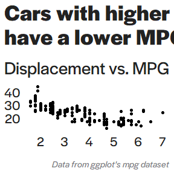

```r
# base plot we will reuse in this section
plt <- ggplot(ggplot2::mpg, aes(displ, hwy)) +
  geom_point() +
  labs(
    title = "Cars with higher displacement\nhave a lower MPG",
    subtitle = "Displacement vs. MPG",
    caption = "Data from ggplot's mpg dataset",
    x = "Engine Displ.",
    y = "MPG"
  )

plt +
  tntp_style()
```

### Setting font family and font sizes

We will highlight two parameters to `tntp_style()` that can help customize your plot.

*`family`*

The `family` parameter lets you set the text font family. This changes the font family for all items, including plot and axis titles, legend titles and text, and axis text. The parameter defaults to ‘Halyard Display’, TNTP’s font style, but uses ‘sans’ if ‘Halyard Display’ is not available. You will receive a warning if your specified font is not found. You can also specify a separate header font using the `header_family` parameter.

You will need to manually import additional fonts, including the Halyard fonts, using the `extrafont` package before they are available to R. Follow these steps to import fonts:

1. Download the Halyard Display Fonts in .ttf forms from the Data Analytics Sharepoint Document Library under the “Fonts” category.
2. Open the fonts folder on your laptop (Settings -> Personalization -> Fonts) and drag and drop the Halyard Fonts there to install them on your computer.
3. In RStudio, install the `extrafont` package with `install.packages("extrafont")`.
4. Import fonts into the extrafont database with `extrafont::font_import()`. This only needs to be done once. The process is long, and can be significantly shortened by only importing the Halyard fonts using `extrafont::font_import(pattern = "Halyard")`.
5. Register the extra fonts with R using `extrafont::loadfonts()`. This needs to be done once each R session, but will be done automatically when loading the `tntpr` library.

You can check to see which fonts are available to R with `windowsFonts()` on Windows or `quartzFonts()` on Mac.

*`base_size`*

The `tntp_style()` function allows a parameter called `base_size` which controls font sizes. The default value is 28 and the recommended minimum is 15. The number represents the plot title’s font size. Other font sizes, such as subtitles, axis labels and text, and legend labels and text will also be adjusted based on the `base_size` value.

Below are the font sizes when `base_size` is set to the default of 28:

- Plot title: 28
- Plot subtitle: 22.4
- Caption: 11.2
- Axis title: 16.8
- Axis text: 16.8

### Further customizing plots outside `tntp_style()`

`tntp_style()` adds TNTP’s `ggplot2` theme to your plot. Users needing more customization can stack themes by adding an additional `theme()` layer **after** adding `tntp_style()`. For example, the following plot sets the font to ‘sans’ and the font size to 20 in `tntp_style()`. It then manually changes to subtitle font to ‘serif’ and the subtitle size to 25 in an additional `theme()`. *Please don’t use this combination in a real plot!*

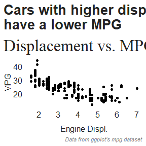

```r
plt +
  tntp_style(show_axis_titles = TRUE, family = "sans", base_size = 20) +
  theme(plot.subtitle = ggplot2::element_text(family = "serif", size = 25))
```

You can also add theme elements that do not coincide with a parameter of `tntp_style()`. For example, here we add a border around the plot with a theme element.

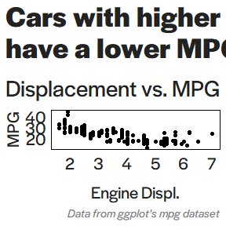

```r
plt +
  tntp_style(show_axis_titles = TRUE) +
  theme(panel.border = element_rect(color = "black", fill = NA))
```

To see all available settings you can adjust with a theme element, see the documentation for `?theme`.

## Using TNTP brand colors

The `tntpr` package includes functions to allow you to easily use TNTP brand colors in your visualizations.

### Colors

The primary function you’ll use is `tntp_colors()`, which takes in human-friendly color names as arguments and returns a character vector of the equivalent hex codes:

```r
tntp_colors("green", "mint")
```

```
#> [1] "#317D5C" "#E2EDDC"
```

A companion function is `show_tntp_colors()`, which will make a quick display of the given colors in the plot window.

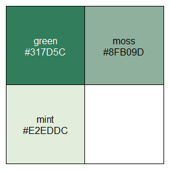

```r
show_tntp_colors("green", "moss", "mint")
```

You can also use `show_tntp_colors()` with no color arguments to display all available colors and names:

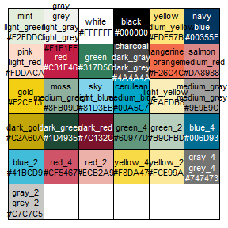

```r
# Note: the cex_label parameter is used to adjust the relative font size
show_tntp_colors(cex_label = 0.7)
```

### Palettes

Some color palettes are used frequently in visualizations. The `tntp_palette()` function allows you to access these pre-determined palettes more easily:

```r
tntp_palette("likert_6")
```

```
#> [1] "#C2A60A" "#F2CF13" "#FDE57B" "#8FB09D" "#317D5C" "#1D4935"
```

Palettes can be reversed by setting `reverse = TRUE`, and can be quickly displayed using the `show_tntp_palette()` function:

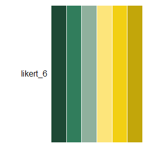

```r
show_tntp_palette("likert_6", reverse = TRUE)
```

For a list and visualization of all pre-set palettes, run the function with no arguments:

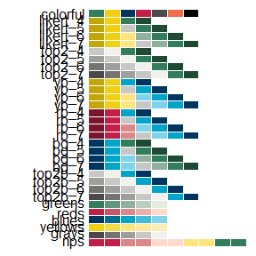

```r
show_tntp_palette()
```

The example plots below will show how to incorporate these functions into your ggplot2 visualizations.

# Example Plots

We will now show examples of plots that we frequently use at TNTP using a fake data set from the `tntpr` package. Let’s first load and clean the data set.

```r
# load fake data into global environment
# remove all salaries of 0
county_data <- tntpr::fake_county |>
  filter(t_salary > 0)

avg_salary <- county_data |>
  filter(t_salary != 0) |>
  group_by(school_year) |>
  summarize(avg_salary = mean(t_salary, na.rm = TRUE), .groups = "drop")
```

We will lower the font size for all plots to 16.

```r
base_font_size <- 16
```

## Make a line chart

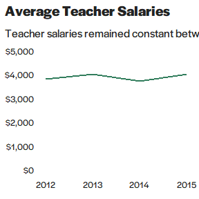

```r
#Make plot
ggplot(avg_salary, aes(x = school_year, y = avg_salary)) +
  geom_line(colour = tntp_colors("green"), linewidth = 1) +
  scale_y_continuous(labels = scales::dollar, limits = c(0, 5000)) +
  labs(
    title="Average Teacher Salaries",
    subtitle = "Teacher salaries remained constant between 2012 and 2015"
  ) +
    tntp_style(base_size = base_font_size)
```

## Make a multiple line chart

Note that in the multiple line chart, we overwrote `ggplot2`’s default color scheme to incorporate TNTP colors. We pulled the hex codes for the colors we wanted to use with `tntp_palette()` and added them to the chart with `scale_colour_manual()`.

```r
#Prepare data
school_salary <- county_data |>
  filter(t_salary != 0) |>
  group_by(school_year, school_name) |>
  summarize(avg_salary = mean(t_salary, na.rm = TRUE), .groups = "drop")

# create list of school names so we can easily filter data set for the number of schools we want
school_names <- unique(school_salary$school_name)

# only plot two schools
line_plot_schools <- school_salary |>
  filter(school_name %in% school_names[1:3])
```

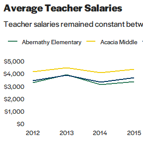

```r
ggplot(line_plot_schools, aes(x = school_year, y = avg_salary, color = school_name)) +
  geom_line(linewidth = 1) +
  scale_y_continuous(labels = scales::dollar, limits = c(0, 5000)) +
  scale_colour_manual(values = tntp_palette("colorful")) +
  labs(
    title="Average Teacher Salaries",
    subtitle = "Teacher salaries remained constant between 2012 and 2015"
  ) +
  tntp_style(base_size = base_font_size)
```

## Make a bar chart

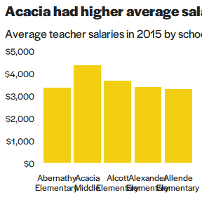

```r
#Prepare data
bar_df <- school_salary |>
  filter(
    school_year == 2015,
    school_name %in% school_names[1:5]
  ) |>
  # add line breaks for better plotting
  mutate(school_name = str_wrap(school_name, 7))

ggplot(bar_df, aes(x = school_name, y = avg_salary)) +
  geom_bar(stat="identity",
           position="identity",
           fill= tntp_colors("gold")) +
  scale_y_continuous(labels = scales::dollar, limits = c(0, 5000)) +
  labs(
    title="Acacia had higher average salaries in 2015",
    subtitle = "Average teacher salaries in 2015 by school"
  ) +
  tntp_style(base_size = base_font_size)
```

## Make a stacked bar chart

The stacked bar chart uses percentages on the y-axis. Note the formatting of the y-axis to create the percentages: `scale_y_continuous(labels = scales::percent, limits = c(0,1))`. We set `limits = c(0,1)` to ensure the y-axis limits run from 0% to 100%. When working with percentages, the axis should (almost) always run from 0% to 100%. Additionally, in `geom_bar()` we set `stat = "identity"`. This tells `ggplot2` to plot the data as-is and to not aggregate the data when making the plot. It is often easier to aggregate data outside of `ggplot2`, more transparent, and easier to check. We could have also replaced `geom_bar(stat = "identity", position = "stack")` with `geom_col()` (no parameters needed) to arrive at the same plot.

```r
#prepare data
stacked_df <- county_data |>
  filter(
    school_year == 2015,
    school_name %in% school_names[1:5]
  ) |>
  mutate(t_salary_cut = cut(t_salary,
                    breaks = c(0, 2500, 3500, 4500, 10000),
                    labels = c("under $2.5k", "$2.5k-$3.5k", "$3.5k-$4.5k", "$4.5k+"))) |>
  group_by(school_name, t_salary_cut) |>
  summarise(n_cut_school = n(), .groups = "drop_last") |>
  mutate(
    n_cut_salary = sum(n_cut_school, na.rm = TRUE),
    perc_in_each_cut = n_cut_school / n_cut_salary
  )  |>
  # add line breaks for better plotting
  mutate(school_name = str_wrap(school_name, 7))

#set order of stacks by changing factor levels
stacked_df$t_salary_cut = factor(stacked_df$t_salary_cut, levels = rev(levels(stacked_df$t_salary_cut)))
```

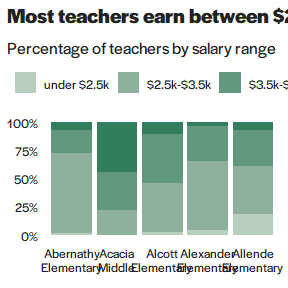

```r
ggplot(
  data = stacked_df,
  aes(x = school_name, y = perc_in_each_cut, fill = t_salary_cut)
) +
  geom_bar(stat = "identity", position = "stack") +
  scale_y_continuous(labels = scales::percent, limits = c(0,1)) +
  scale_fill_manual(values = tntp_palette("greens")) +
  labs(title = "Most teachers earn between $2.5K and $4.5K",
       subtitle = "Percentage of teachers by salary range") +
  theme(legend.position = "top",
        legend.justification = "left") +
  guides(fill = guide_legend(reverse = TRUE)) +
  tntp_style(base_size = base_font_size)
```

This example shows proportions, but you might want to make a stacked bar chart showing number values instead - this is easy to change!

The value passed to the `position` argument will determine if your stacked chart shows proportions or actual values.

`position = "fill"` will draw your stacks as proportions, and `position = "identity"` will draw number values.

## Make a grouped bar chart

Making a grouped bar chart is very similar to making a bar chart. You just need to change `position = "identity"` to `position_dodge2(preserve = "single")`.

Note the use of the named vector `colors_to_use` to expressly map colors to values. This is a safe way to ensure we are properly mapping colors to values.

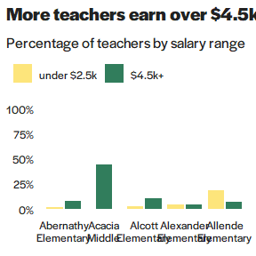

```r
# only plot the lowest and highest earning groups
earnings_to_keep <- levels(stacked_df$t_salary_cut)[c(4,1)]

# map bar colors to values
colors_to_use <- tntp_colors("yellow", "green") |>
  set_names(earnings_to_keep)

dodged_df <- stacked_df |>
  # only plot the lowest and highest earning groups
  filter(t_salary_cut %in% !!earnings_to_keep) |>
  # switch order of factors so that the lowest earnings plot first
  mutate(t_salary_cut = factor(t_salary_cut, levels = earnings_to_keep))

ggplot(dodged_df, aes(x = school_name, y = perc_in_each_cut, fill = t_salary_cut)) +
    geom_bar(stat = "identity", position = position_dodge2(preserve = "single")) +
    scale_y_continuous(labels = scales::percent, limits = c(0,1)) +
    scale_fill_manual(values = colors_to_use) +
    labs(title = "More teachers earn over $4.5k than under $2.5k",
         subtitle = "Percentage of teachers by salary range") +
    tntp_style(base_size = base_font_size)
```

## Make a scatterplot

```r
# create data set showing school test scores and average school salaries
scores_salary <- county_data |>
  group_by(school_name) |>
  summarize(
    avg_test_score = mean(sch_ela_avg + sch_math_avg, na.rm=FALSE),
    avg_salary = mean(t_salary, na.rm = FALSE),
    enrollment = mean(sch_enroll_2015, na.rm = TRUE),
    .groups = "drop"
  ) |>
  mutate(perc_rank_test_score = percent_rank(avg_test_score)) |>
  drop_na()
```

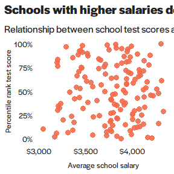

```r
ggplot(scores_salary, aes(avg_salary, perc_rank_test_score)) +
  geom_point(color = tntp_colors("tangerine"), alpha = 0.9, size = 3) +
  labs(
    title = "Schools with higher salaries do not have higher test scores",
    subtitle = "Relationship between school test scores and salaries",
    x = "Average school salary",
    y = "Percentile rank test score"
  ) +
  scale_x_continuous(labels = scales::dollar) +
  scale_y_continuous(labels = scales::percent) +
  tntp_style(base_size = base_font_size, show_axis_titles = TRUE)
```

## Make a dumbbell chart

Another way of showing difference is a dumbbell chart. Note that `geom_dumbell()` comes from the [`ggalt`](https://yonicd.github.io/ggalt/index.html) package.

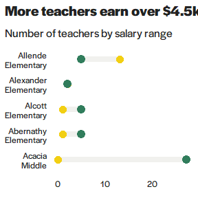

```r
dumbbell_df <- dodged_df |>
  pivot_wider(id_cols = "school_name", names_from = "t_salary_cut", values_from = "n_cut_school") |>
  mutate(across(where(is.numeric), ~replace_na(.x, 0)))

ggplot(dumbbell_df, aes(x = `under $2.5k`, xend = `$4.5k+`, y = fct_reorder(school_name, `under $2.5k`)), group = school_names) +
  geom_dumbbell(
    color = tntp_colors("light_grey"),
    size = 3,
    colour_x = tntp_colors("gold"),
    colour_xend = tntp_colors("green"),
    show.legend = TRUE
  ) +
  labs(title = "More teachers earn over $4.5k than under $2.5k",
       subtitle = "Number of teachers by salary range",
       x = "Number of teachers earnign a given salary") +
  tntp_style(base_size = base_font_size)
```

## Make a histogram

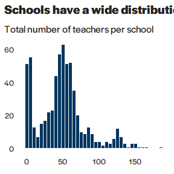

```r
# number of teachers per school
number_teachers_school <- county_data |>
  count(school_year, school_name)

ggplot(number_teachers_school, aes(n)) +
  geom_histogram(binwidth = 5, colour = "white", fill = tntp_colors('navy')) +
  labs(
    title = "Schools have a wide distribution in the number of teachers",
    subtitle = "Total number of teachers per school",
    x = "Number of teacher in school",
    y = "Count"
  ) +
  tntp_style(base_size = base_font_size)
```

## Making density plots

The [`ggridges`](https://wilkelab.org/ggridges/) package contains additional plots for plotting distributions using ridgeline plots.

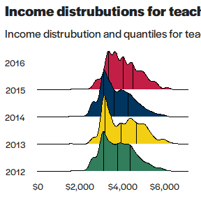

```r
ggplot(county_data, aes(x = t_salary, y = school_year, group = school_year, fill = factor(school_year))) +
  geom_density_ridges(quantile_lines = TRUE, quantiles = 4) +
  scale_x_continuous(labels = scales::dollar) +
  labs(title = "Income distrubutions for teachers has remained constant",
       subtitle = "Income distrubution and quantiles for teachers") +
  tntp_style(base_size = base_font_size) +
  theme(legend.position = "none") +
  scale_fill_manual(values = tntp_palette("colorful"))
```

# Working with survey data

We often work with survey data at TNTP. Here we will highlight a couple examples of plotting survey data. We will use the `teacher_survey` data set in the `tntpr` package, which is a fake teacher survey. Let’s start by loading the data set and calculating averages.

```r
teacher_survey <- tntpr::teacher_survey

# the y-axis will contain text of an entire survey question
# we want to place line breaks in this text so plots look better
axis_line_breaks <- 40

# scales in HE questions, in order starting with the strongest
agree_disagree_scale <- rev(c("Strongly Agree", "Agree", "Somewhat Agree", "Somewhat Disagree", "Disagree", "Strongly Disagree"))

# put survey into long form and clean up question names
teacher_survey_he <- teacher_survey |>
  select(-timing) |>
  pivot_longer(cols = everything(), names_to = "question", values_to = "response")

# calculate percentage of responses to each high expectations question
teacher_survey_he_perc <- teacher_survey_he |>
  drop_na("response") |>
  # calculate the number of responses for each response option
  count(question, response, name = "n_response") |>
  # calculate the number of responses for each question
  group_by(question) |>
  mutate(n_question = sum(n_response)) |>
  ungroup() |>
  # calculate percentages
  mutate(
    # calculate percentages
    percent = n_response / n_question,
    # make a column that is text of the percent for plotting
    percent_pretty = scales::percent(percent, accuracy = 1)
  )

# calculate percentage of strongly agree and agree
teacher_survey_he_perc <- teacher_survey_he_perc |>
  mutate(scale_strength = ifelse(response %in% !!agree_disagree_scale[c(5,6)], "Strong response", "Weak response")) |>
  group_by(question, scale_strength) |>
  mutate(strong_response_percent = sum(percent)) |>
  ungroup() |>
  mutate(
    strong_response_percent = ifelse(response == "Agree", strong_response_percent, NA),
    # create line breaks for questions ,which will make plots look better
    question = str_wrap(question, axis_line_breaks),
    response = factor(response, levels = agree_disagree_scale)
  )
```

## Plot likert items - highlights top two

The first plot calls out the two highest response values, “Strongly Agree” and “Agree”. Note that the `tntp_style()` function does not alter the font size or family of the text within `geom_text()` so we set it manually.

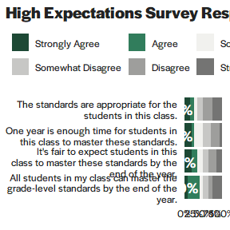

```r
ggplot(teacher_survey_he_perc, aes(percent, question, fill = response)) +
  geom_col() +
  geom_text(
    aes(label = scales::percent(strong_response_percent, accuracy = 1), x = strong_response_percent),
    color = "white", fontface = "bold", family = "Halyard Display", size = 5, hjust = 1.05
  ) +
  scale_x_continuous(labels = scales::percent, limits = c(0,1)) +
  scale_fill_manual(values = tntp_palette("top2_6"), drop = FALSE) +
  guides(fill=guide_legend(nrow=2, byrow=TRUE, reverse = TRUE))  +
  labs(title = "High Expectations Survey Responses") +
  tntp_style(base_size = base_font_size)
```

## Plot likert items - diverging

Diverging charts have been made much simpler with the introduction of the `position_diverge()` function in tntpr. In interactive use, if you have both `ggplot2` and `tntpr` loaded this can be called like other positions using a string:

```r
geom_col(position = "diverge")
```

However for non-interactive code such as examples and books (like this one), it needs be called using the full function:

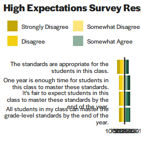

```r
ggplot(teacher_survey_he_perc, aes(x = percent, y = question, fill = fct_rev(response))) +
  geom_col(position = position_diverge()) +
  scale_fill_manual(
    values = tntp_palette("likert_6"),
    drop = FALSE,
    breaks = agree_disagree_scale,
    labels = agree_disagree_scale
  ) +
  geom_vline(aes(xintercept = 0), linetype = 1, linewidth = 1.2, alpha = .7) +
  scale_x_continuous(limits = c(-1, 1), breaks = seq(-1, 1, .25), labels = \(x) scales::percent(abs(x))) +
  labs(title = "High Expectations Survey Responses") +
  tntp_style(base_size = base_font_size)
```

Calling as a function also allows for additional customization through the parameters `break_after`, `fill`, `vjust`, and `reverse`

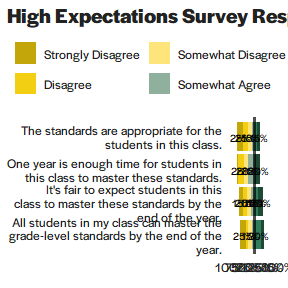

```r
ggplot(teacher_survey_he_perc, aes(x = percent, y = question, fill = fct_rev(response))) +
  geom_col(position = position_diverge(break_after = "Agree")) +
  geom_text(aes(label = ifelse(percent > 0.1, percent_pretty, "")),
            position = position_diverge(break_after = "Agree", vjust = 0.5),
            family = "Halyard Display", size = 3) +
  scale_fill_manual(
    values = tntp_palette("likert_6"),
    drop = FALSE,
    breaks = agree_disagree_scale,
    labels = agree_disagree_scale
  ) +
  geom_vline(aes(xintercept = 0), linetype = 1, linewidth = 1.2, alpha = .7) +
  scale_x_continuous(limits = c(-1, 1), breaks = seq(-1, 1, .25), labels = \(x) scales::percent(abs(x))) +
  labs(title = "High Expectations Survey Responses") +
  tntp_style(base_size = base_font_size)
```